# GLGC - Examination of heterogenous SNPs across populations

A.Chong

2024-02-01

**Outline**

- 1. `organise_data.r` extracts LDL-lowering drug target regions from each population
- 2. Estimate Cochrane’s Q for each SNP across populations to identify any SNPs that have differential effects
- 3. Examine differences in SNP effect size for heterogenous SNPs across populations

Load organised data

```r
library(dplyr)
library(tidyr)
```

```r
library(ggplot2)
ex <- readRDS("C:/Users/ac14629/OneDrive - University of Bristol/MRC_cross_population_network/LDL_analysis/pop_extract_clumped.rds")
ex <- ex[!is.na(ex$Drug), ]
pops <- c("AFR", "EAS", "EUR", "HIS", "SAS")

print(ex)
```

```
## # A tibble: 29 × 15
##    rsid        chr    pos   eaf ea    oa        pval    beta      se     n pop
##    <chr>     <int>  <int> <dbl> <chr> <chr>    <dbl>   <dbl>   <dbl> <int> <chr>
##  1 rs115911…     1 5.55e7 0.997 G     T     7.20e-16  0.373  0.0449  91672 AFR
##  2 rs412948…     1 5.55e7 0.972 C     T     1.57e- 5 -0.0673 0.0151  94622 AFR
##  3 rs1165287     1 5.55e7 0.241 A     G     1.26e-51  0.0863 0.00555 94623 AFR
##  4 rs505151      1 5.55e7 0.739 A     G     4.64e-82 -0.104  0.00526 94623 AFR
##  5 rs4704210     5 7.46e7 0.327 C     G     3.20e-12  0.0359 0.00500 92003 AFR
##  6 rs412796…     7 4.46e7 0.968 G     T     2.2 e- 3 -0.0442 0.0140  92934 AFR
##  7 rs412948…     1 5.55e7 0.966 C     T     3.59e- 8  0.0800 0.0139  82587 EAS
##  8 rs1165287     1 5.55e7 0.767 A     G     1.95e-12  0.0477 0.00650 77945 EAS
##  9 rs505151      1 5.55e7 0.948 A     G     2.59e-11 -0.0794 0.0114  82587 EAS
## 10 rs4704210     5 7.46e7 0.502 C     G     1.28e-54  0.0812 0.00500 82587 EAS
## # ℹ 19 more rows
## # ℹ 4 more variables: snpid <chr>, Drug <chr>, `Target gene` <chr>,
## #   Function <chr>
```

**Define heterogeneity test**

```r
## Heterogeneity analysis
# TODO - allow
fixed_effects_meta_analysis <- function(beta_vec, se_vec) {
    w <- 1 / se_vec^2
    beta <- sum(beta_vec * w, na.rm=T) / sum(w, na.rm=T)
    se <- sqrt(1 / sum(w, na.rm=T))
    pval <- pnorm(abs(beta / se), lower.tail = FALSE)
    Qj <- w * (beta-beta_vec)^2
    Q <- sum(Qj, na.rm=T)
    Qdf <- sum(!is.na(beta_vec))-1
    if(Qdf == 0) Q <- 0
    Qjpval <- pchisq(Qj, 1, lower.tail=FALSE)
    Qpval <- pchisq(Q, Qdf, lower.tail=FALSE)
    return(list(beta=beta, se=se, Q=Q, Qdf=Qdf, Qpval=Qpval, Qj=Qj, Qjpval=Qjpval))
}

#' Test for heterogeneity of effect estimates between populations
#'
#' @description For each SNP this function will provide a Cochran's Q test statistic - a measure of heterogeneity of effect sizes between populations. A low p-value means high heterogeneity.
#' In addition, for every SNP it gives a per population p-value - this can be interpreted as asking for each SNP is a particular giving an outlier estimate.
#'
#' @param sslist Named list of data frames, one for each population, with at least beta, se and snp columns
#'
#' @return List
#' - Q = vector of p-values for Cochrane's Q statistic for each SNP
#' - Qj = Data frame of per-population outlier q values for each SNP
heterogeneity_test <- function(sslist) {
    j <- combine_data(sslist)
    b <- j %>% dplyr::select(starts_with("beta")) %>% as.matrix()
    se <- j %>% dplyr::select(starts_with("se")) %>% as.matrix()
    o <- lapply(1:nrow(b), \(i) {
        fixed_effects_meta_analysis(as.numeric(b[i,]), as.numeric(se[i,]))
    })
    Q <- tibble(snpid = j$snpid, Qpval = sapply(o, \(x) x$Qpval))
    Qj <- lapply(o, \(x) x$Qjpval) %>% do.call(rbind, .) %>%
        as_tibble()

    names(Qj) <- names(sslist)
    Qj$snpid <- j$snpid
    return(list(Q=Q, Qj=Qj))
}


combine_data <- function(sslist) {
    j <- sslist[[1]] %>% select(snpid, beta, se)
    for(i in 2:length(sslist))
    {
        j <- full_join(j, sslist[[i]] %>% select(snpid, beta, se), by="snpid")
    }
    j %>% dplyr::select(starts_with("beta"))
    return(j)
}
```

*For each SNP that is present in at least 2 populations, estimate the heterogeneity of effects between the populations. Do this two ways*

*- `Q` - global heterogeneity test for the SNP across all populations (Cochrane’s Q)* *- `Qj` - the deviation of each population contributing to the global heterogeneity Q*

```r
exl <- lapply(pops, \(x) subset(ex, pop==x) %>% subset(!duplicated(snpid)))
names(exl) <- pops

o <- heterogeneity_test(exl)
o$Q$fdr <- p.adjust(o$Q$Qpval, "fdr")
min(o$Q$fdr)
```

```
## [1] 1.100398e-11
```

Strong evidence of heterogeneity.

```r
selsnpid <- subset(o$Q, Qpval < 0.05)$snpid
subset(o$Qj, snpid %in% selsnpid)
```

```
## # A tibble: 3 × 6
##        AFR      EAS    EUR   HIS   SAS snpid
##      <dbl>    <dbl>  <dbl> <dbl> <dbl> <chr>
## 1 2.23e-11 0.000955 0.0831 0.194 0.445 1:55513183_C_T
## 2 2.76e- 8 0.232    0.174  0.108 0.343 1:55520212_A_G
## 3 1.69e- 9 0.00242  0.302  0.371 0.203 5:74635225_C_G
```

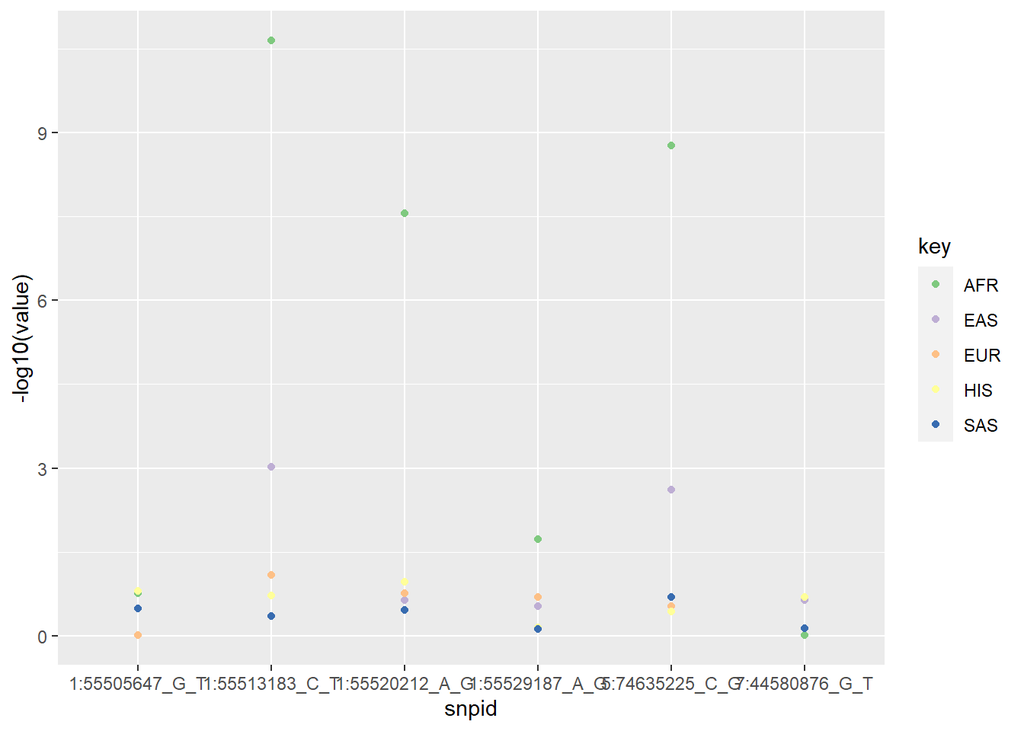

```r
gather(as.data.frame(o$Qj), "key", "value", -snpid) %>%
ggplot(., aes(x=snpid, y=-log10(value))) +
geom_point(aes(colour=key)) +
scale_colour_brewer(type="qual")
```

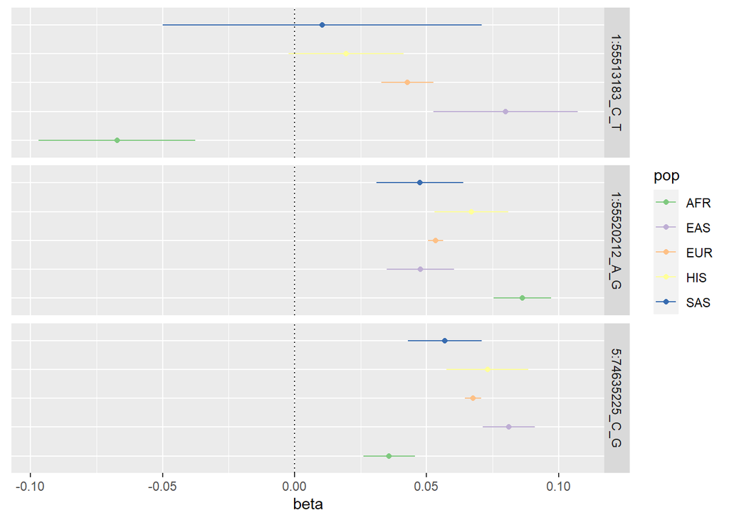

```r
ex %>%
    filter(snpid %in% selsnpid) %>%
    ggplot(., aes(x = beta, y = pop)) +
    geom_point(aes(colour = pop)) +
    geom_errorbarh(aes(colour = pop, xmin = beta - se * 1.96, xmax = beta + se * 1.96), height = 0) +
    facet_grid(snpid ~ .) +
    geom_vline(xintercept = 0, linetype = "dotted") +
    scale_colour_brewer(type = "qual") +
    theme(axis.title.y = element_blank(),
          axis.text.y = element_blank(),
          axis.ticks.y = element_blank())
```

**Examine why there are differences in SNP effect size in AFR population compared to the other populations by:** ** - Plot region of interest** ** - Check allele frequency against AFR reference panel**

```r
dat <- read.table("C:/Users/ac14629/OneDrive - University of Bristol/MRC_cross_population_network/LDL_analysis/GLGC_AFR_metaanalysis_chr1_5_with_ref_panel.results", header = T)
dat_1 <- dat %>% filter(CHROM==1)
dat_5 <- dat %>% filter(CHROM==5)
```

**Compare GLGC allele frequencies for SNPs of interest with 1000G AFR reference panel**

```r
snps <- c("rs41294821","rs1165287", "rs4704210")

af <- dat %>%
  filter(rsID %in% snps) %>%
  select("rsID", "CHROM", "POS_b37", "REF", "ALT", "POOLED_ALT_AF", "MAF_AFR_REF", "EFFECT_SIZE", "SE", "pvalue_GC", "MAF_AFR_REF")

print(af)
```

```
##         rsID CHROM  POS_b37 REF ALT POOLED_ALT_AF MAF_AFR_REF EFFECT_SIZE
## 1 rs41294821     1 55513183   C   T        0.0277     0.02042   0.0672827
## 2  rs1165287     1 55520212   G   A        0.2410     0.19060   0.0863166
## 3  rs4704210     5 74635225   G   C        0.3270     0.31850   0.0358606
##           SE pvalue_GC
## 1 0.01514320  1.57e-05
## 2 0.00555079  1.26e-51
## 3 0.00500247  3.20e-12
```

The all SNPs show similar allele frequencies to the AFR reference allele panel (i.e. POOLED_ALT_AF and MAF_AFR_REF).

**Allele frequency: Chr 1 region**

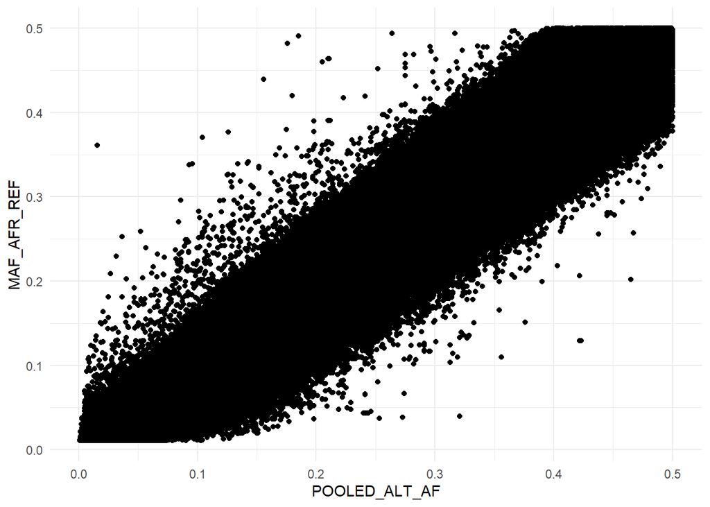

```r
plot_af_1 <- ggplot(dat_1, aes(x=POOLED_ALT_AF, y =MAF_AFR_REF)) +
  geom_point() +
  theme_minimal()

print(plot_af_1)
```

Allele frequency for GLGC AFR and AFR reference panel in chromosome 1 looks consistent.

**Allele frequency: Chr 5 region**

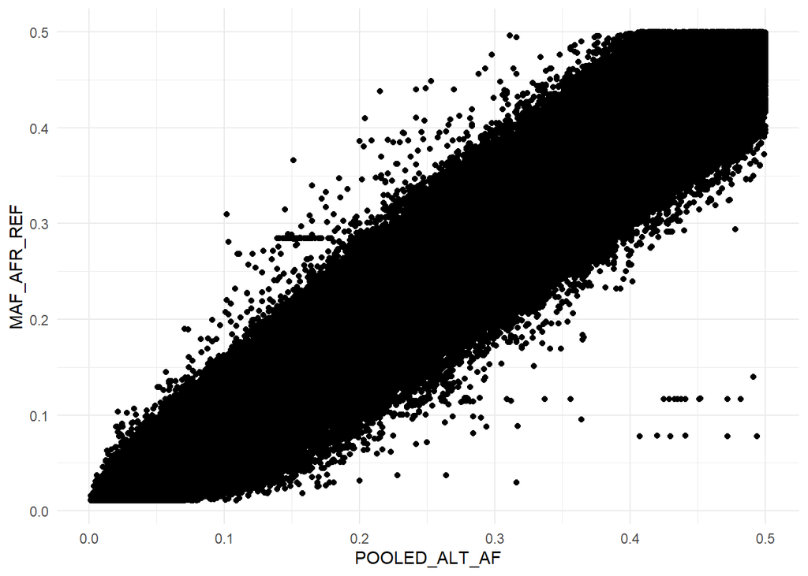

```r
plot_af_5 <- ggplot(dat_5, aes(x=POOLED_ALT_AF, y =MAF_AFR_REF)) +
  geom_point() +
  theme_minimal()

print(plot_af_5)
```

Allele frequency for GLGC AFR and AFR reference panel in chromosome 5 looks consistent.